# South African RSTR Data cleaning

Kim Dill-McFarland, kadm@uw.edu

version February 10, 2021

# Background

The purpose of this workflow is to complete basic data cleaning of metadata and RNA-seq libraries generated from the above experiments. This includes 1) removing low coverage libraries, 2) filtering rare genes, 3) removing outlying libraries, and 4) normalizing for RNA composition.

# Setup

Load packages

```r
# Data manipulation and figures
library(tidyverse)
library(janitor)
  # Modify ggplot figures to non-overlapping text labels
  library(ggrepel)
  # Modify ggplot data order within facets
  library(drlib)
  # Plot log scales
  library(scales)
  #Multi-panel figures
  library(cowplot)

# Empirical analysis of digital gene expression data
## Data normalization
library(edgeR)

# Print pretty table to knit file
library(knitr)
library(kableExtra)
  options(knitr.kable.NA = '')

#Create 'not in' operator
`%notin%` <- Negate(`%in%`)
```

Set seed

```r
set.seed(4389)
```

# Customization

Set variable names and cutoffs for this workflow.

```r
#Provide file basename
#This will be appended to the start of all file names saved to the disk
basename <- "RSTR_SA"

#List main variables of interest
#Will be used to visualize data in tables and plots
#If > 2 variables provided, plots are not colored by variables
vars_of_interest <- c("condition","Sample_Group",
                      "gender","age","bmi","ethnic",
                      "occupationlevel","workingunderground",
                      "YearsWorkedUnderground",
                      "bcgscar")

# Define cutoffs
#Total sequences MINIMUM
count.cut <- 1E6
```

# Read in and format data

## Counts and metadata

```r
#Raw counts table
counts <- readRDS("data_raw/Hawn_SAMacrophage_counts.rds") %>%
  as.data.frame() %>%
  rownames_to_column("geneName")
```

```r
#Get donors in RNAseq dataset
meta <- counts[1,] %>%
  pivot_longer(-geneName, names_to = "libID") %>%
  select(libID) %>%
  separate(libID, into=c("FULLIDNO","condition"), sep="_", remove = FALSE) %>%
  #add addtl metdata
  left_join(read_csv("data_raw/2020.11.05SA.RSTR_Hawn_metadata.csv"),
            by = c("FULLIDNO"="ptID")) %>%
  #Fill in missing RSTR
  mutate(Sample_Group = ifelse(is.na(Sample_Group) & status == "control",
                               "LTBI",
                               ifelse(is.na(Sample_Group) & status == "case",
                               "RSTR", Sample_Group))) %>%
  arrange(libID)
```

#### Check samples

*all libraries in the count data are found in the sample metadata. And vice versa.*

```
## [1] TRUE
```

## Summarize samples

Total libraries

| Sample_Group | condition | n |
| --- | --- | --- |
| LTBI | MEDIA | 30 |
| LTBI | TB | 30 |
| RSTR | MEDIA | 29 |
| RSTR | TB | 29 |

# Data cleaning

## Remove select samples

Remove white participants (6 RSTR) and those that converted/reverted TST or IGRA at 12 months (3 RSTR, 1 LTBI).

```r
meta.filter <- meta %>%
  #Rm white participants
  filter(ethnic != "White/European") %>%
  #Rm converters
  filter(FULLIDNO %notin% c("890-01347-2", "890-01612-7",
                        "890-00658-6", "890-00798-1"))

counts.filter <- counts[,c("geneName", meta.filter$libID)]
```

## Assess library coverage

Calculate total sequences.

```r
tot.seq <- counts.filter %>%
  pivot_longer(-geneName, names_to = "libID") %>%
  group_by(libID) %>%
  summarise(tot.seq = sum(value, na.rm=TRUE), .groups="drop")

#add to metadata
meta.filter <- meta.filter %>%
  full_join(tot.seq)
```

Plot total sequences per library. The minimum total sequences cutoff set above is indicated by a horizontal line.

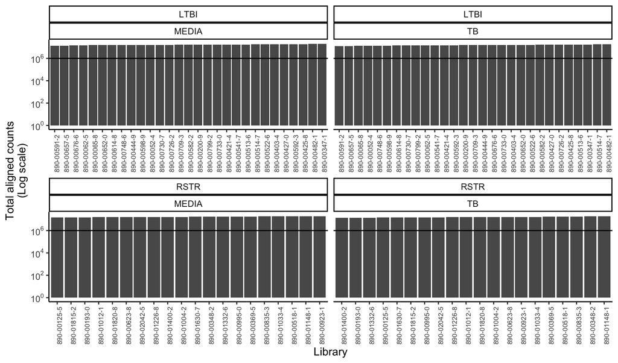

## Filter by library coverage

All libraries have sufficient coverage. Thus, none will be removed.

## Filter protein coding genes

Load key.

```r
key <- read_tsv("data_raw/2020.06.18_HGNC.gene.key.txt") %>%
  clean_names() %>%
  #get all prev and alias symbols
  mutate(previous_symbols = strsplit(as.character(previous_symbols), ", ")) %>%
  mutate(alias_symbols = strsplit(as.character(alias_symbols), ", ")) %>%
  unnest(cols=previous_symbols) %>%
  unnest(cols=alias_symbols) %>%
  rownames_to_column() %>%
  pivot_longer(c(approved_symbol:alias_symbols), values_to = "geneName") %>%
  drop_na(geneName) %>%
  select(-rowname)
```

Filter gene key to protein coding (pc) genes that occur in the count data set and have valid hgnc symbols.

```r
key.pc <- key %>%
  # Keep only valid hgnc symbols
  drop_na(geneName) %>%
  # Keep protein coding genes only
  filter(locus_group == "protein-coding gene") %>%
  # Remove duplicate entries
  distinct(geneName, .keep_all=TRUE) %>%
  # Keep only genes found in dataset
  filter(geneName %in% counts.filter$geneName) %>%
  arrange(geneName)
```

Filter the count data to pc genes as well.

```r
counts.filter.pc <- counts.filter %>%
  filter(geneName %in% key.pc$geneName) %>%
  arrange(geneName)
```

#### Check genes

*all genes in the key are found in the data. And vice versa.*

```
## [1] TRUE
```

## Assess PCA

### Variables of interest

If one or more variables of interest represents significant variation in the data, consider further filtering and normalizing separately. This is most common when multiple sample or cell types exist in the data set.

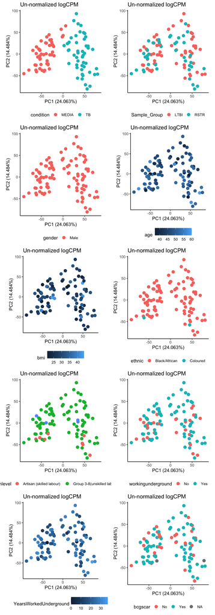

### PCA outliers

Visualize PCA outliers defined as any library with PC1 and/or PC2 values greater than 3 standard deviations away from the PC mean.

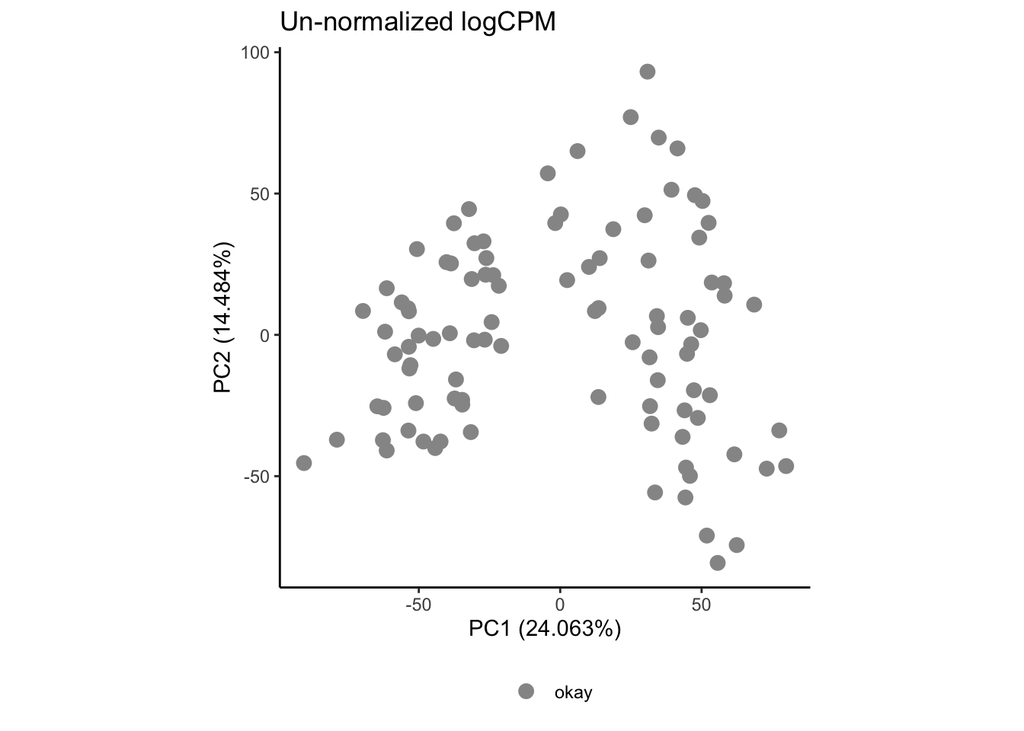

## Filter PCA outliers

No PCA outliers are apparent. Thus, no libraries are removed.

## Create DGEList object

For use in gene filtering with edgeR

```r
dat <- DGEList(
  #count table. move gene names to column names
  counts=as.matrix(column_to_rownames(counts.filter.pc,
                                      "geneName")),
  #metadata
  samples=meta.filter,
  #keep genes in count table
  genes=key.pc)
```

## Filter rare genes

The raw gene sets contain highly variable, low abundance/rare genes. Filter genes without > 0.5 CPM in at least 5% (5) samples.

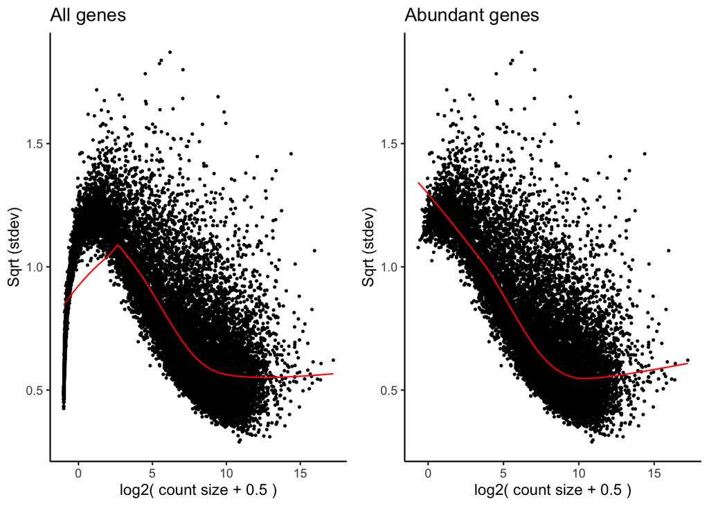

```r
source("https://raw.githubusercontent.com/kdillmcfarland/R_bioinformatic_scripts/master/RNAseq_rare_gene_filter.R")

rare.gene.filter(dat,
                 min.CPM=min.CPM,
                 min.pct=min.pct,
                 name="dat.abund")
```

This removes 4426 (23%) genes.

## Normalize for RNA composition

Calculate factors to scale library sizes.

```r
dat.abund.norm <- calcNormFactors(dat.abund)
```

## Normalize with voom

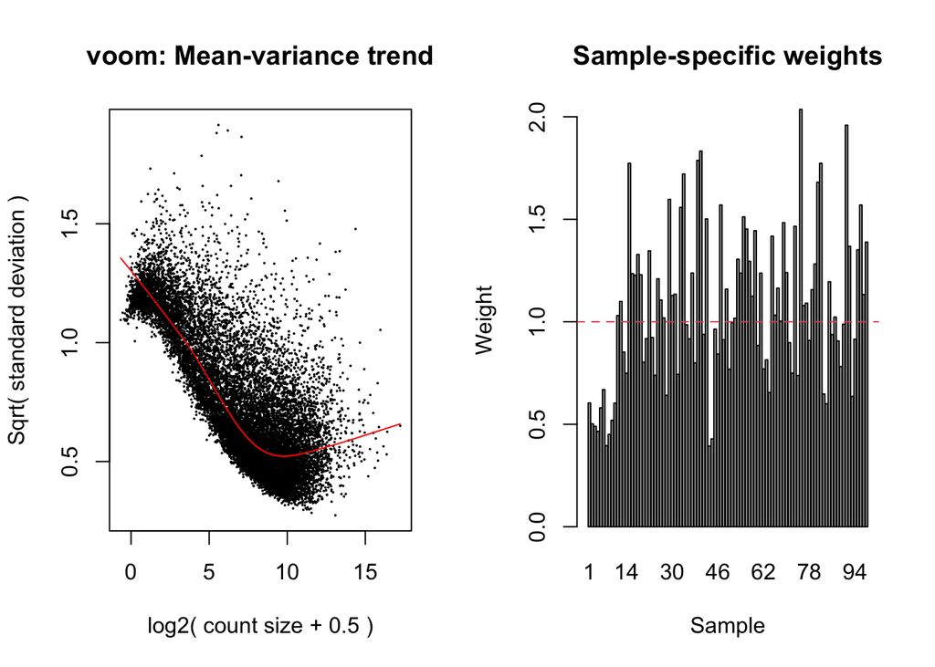

```r
dat.abund.norm.voom <- voomWithQualityWeights(
  dat.abund.norm, design=model.mat, plot=TRUE)
```

## PCA final data set

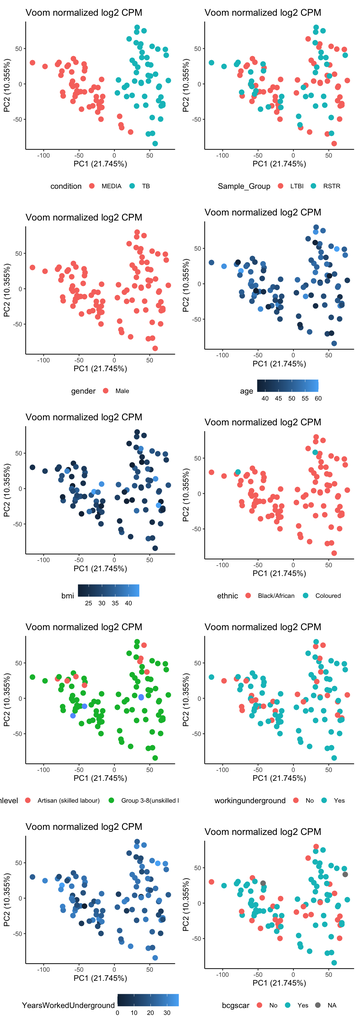

## Summarize cleaning

Libraries removed

| libID | condition | Sample_Group | filter |
| --- | --- | --- | --- |
| 890-00107-5_MEDIA | MEDIA | RSTR | White/European |
| 890-00107-5_TB | TB | RSTR | White/European |
| 890-00112-1_MEDIA | MEDIA | RSTR | White/European |
| 890-00112-1_TB | TB | RSTR | White/European |
| 890-00215-5_MEDIA | MEDIA | RSTR | White/European |
| 890-00215-5_TB | TB | RSTR | White/European |
| 890-00658-6_MEDIA | MEDIA | RSTR | convert/revert |
| 890-00658-6_TB | TB | RSTR | convert/revert |
| 890-00683-4_MEDIA | MEDIA | RSTR | White/European |
| 890-00683-4_TB | TB | RSTR | White/European |
| 890-00785-7_MEDIA | MEDIA | RSTR | White/European |
| 890-00785-7_TB | TB | RSTR | White/European |
| 890-00798-1_MEDIA | MEDIA | LTBI | convert/revert |
| 890-00798-1_TB | TB | LTBI | convert/revert |
| 890-01331-5_MEDIA | MEDIA | RSTR | White/European |
| 890-01331-5_TB | TB | RSTR | White/European |
| 890-01347-2_MEDIA | MEDIA | RSTR | convert/revert |
| 890-01347-2_TB | TB | RSTR | convert/revert |
| 890-01612-7_MEDIA | MEDIA | RSTR | convert/revert |
| 890-01612-7_TB | TB | RSTR | convert/revert |

No libraries were removed for quality or PCA. This leaves the following for analysis.

Total libraries

| Sample_Group | condition | n |
| --- | --- | --- |
| LTBI | MEDIA | 29 |
| LTBI | TB | 29 |
| RSTR | MEDIA | 20 |
| RSTR | TB | 20 |

# Save data

Write as RData

```r
dir.create("data_clean/", showWarnings = FALSE)
save(dat.abund.norm.voom,
     file=paste("data_clean/", basename, "_dat_clean.RData", sep=""))
```

Write counts as table.

```r
#Counts table
write_csv(as.data.frame(dat.abund.norm.voom$E),
          paste("data_clean/", basename, "_counts_voom.csv", sep=""))
```